# African or American?: Conditional Nativism and Black American National Identity *[^1]

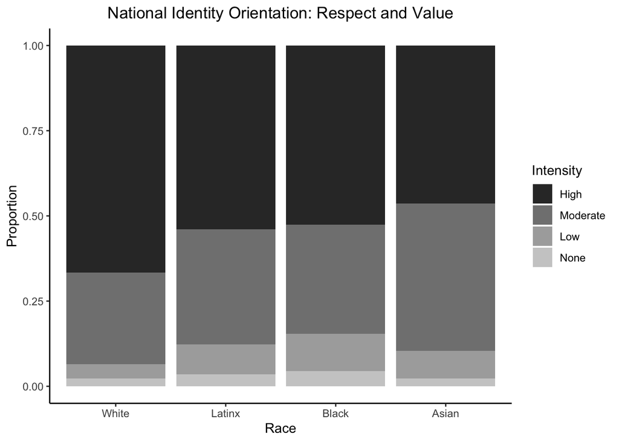

```r
r <- r + labs(title = "National Identity Orientation: Respect and Value",
              x = "Race", y = "Proportion") + theme(plot.title = element_text(hjust = 0.5))
r <- r + scale_fill_grey(start = 0.2, end = 0.8, na.value = "red", name = "Intensity",
                         labels = c("High", "Moderate", "Low", "None"));r
```

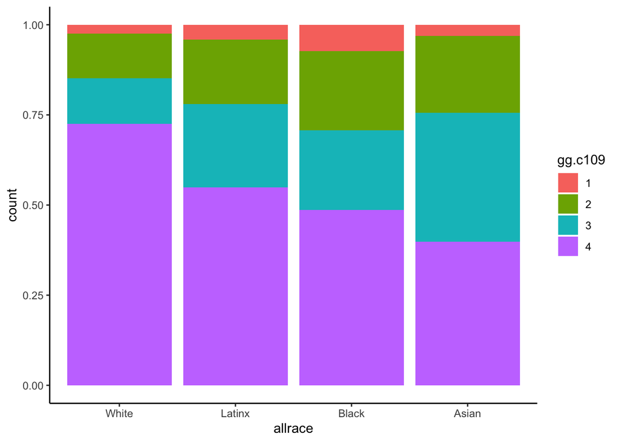

```r
ot <- ggplot(cmps, aes(allrace, fill = gg.c109))
ot <- ot + geom_bar(position = "fill") + theme_classic();ot
```

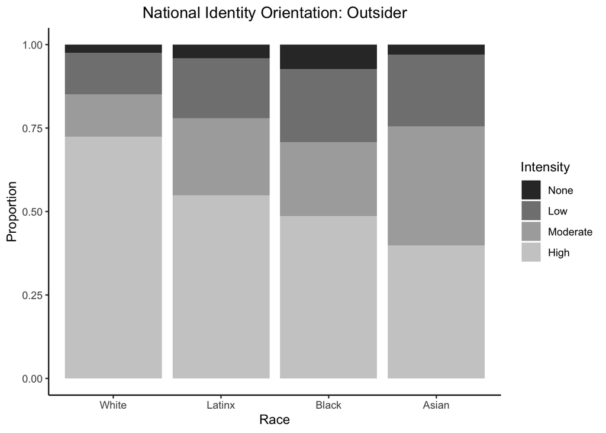

```r
ot <- ot + labs(title = "National Identity Orientation: Outsider",
              x = "Race", y = "Proportion") + theme(plot.title = element_text(hjust = 0.5))
ot <- ot + scale_fill_grey(start = 0.2, end = 0.8, na.value = "red", name = "Intensity",
                         labels = c("None", "Low","Moderate","High"));ot
```

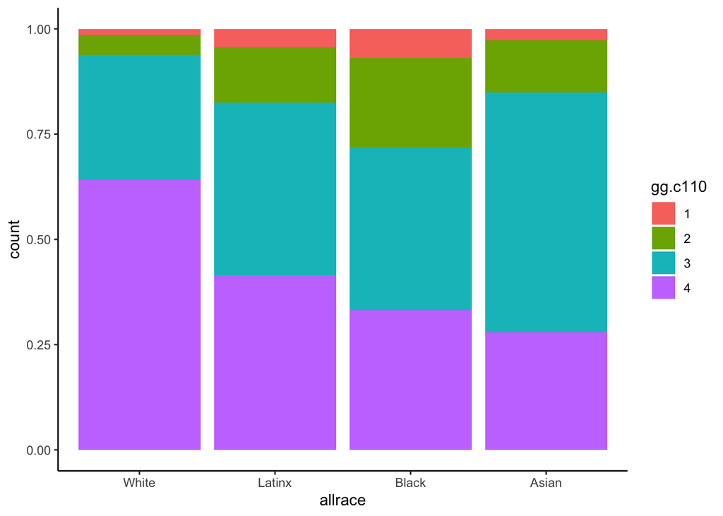

```r
e <- ggplot(cmps, aes(allrace, fill = gg.c110))
e <- e + geom_bar(position = "fill") + theme_classic();e
```

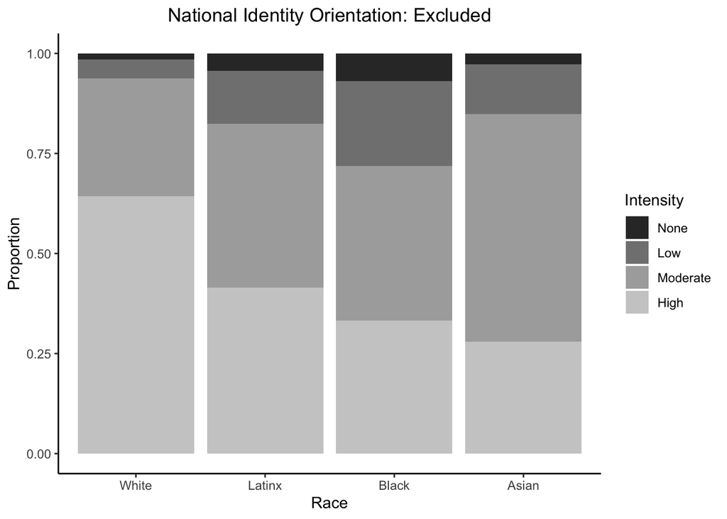

```r
e <- e + labs(title = "National Identity Orientation: Excluded",
              x = "Race", y = "Proportion") + theme(plot.title = element_text(hjust = 0.5))
e <- e + scale_fill_grey(start = 0.2, end = 0.8, na.value = "red", name = "Intensity",
                         labels = c("None", "Low","Moderate","High"));e
```

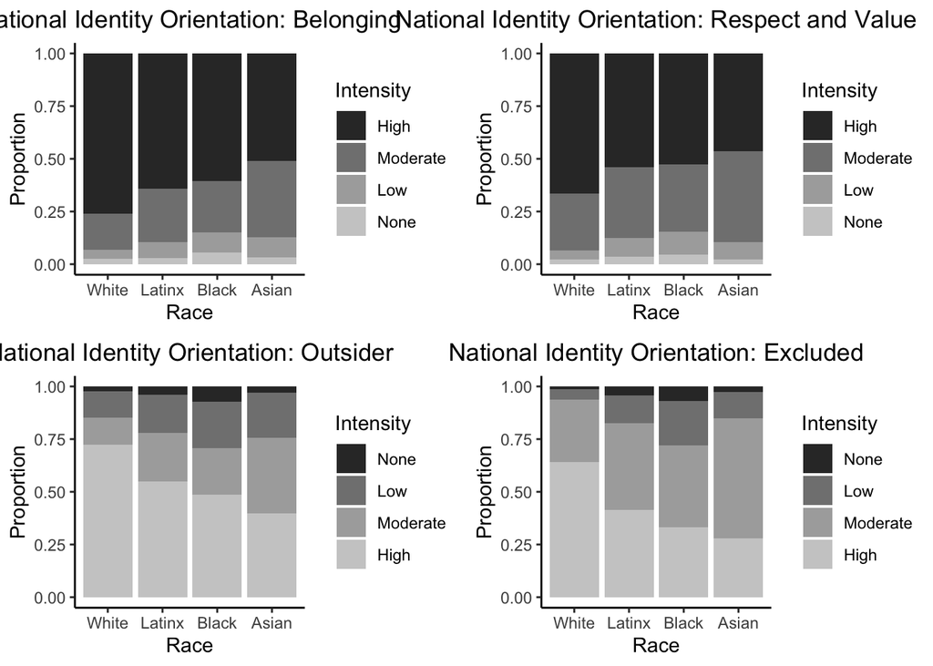

```r
all <-  grid.arrange(b,r,ot,e); all
```

**Figure 1 reports national identity orientation by racial groups. Each dependent variable is a constituent item of the national identity index I use in Model 1. The x-axis reports racial groups while the y-axis reports the proportion of each group that shares the attachment (Collaborative Multi-Racial Post-Election Survey, n = 10,146).**

Black Americans form a different orientation toward American national identity I call conditional nativism. I define conditional nativism as the idea that individual attachment to national identity is conditional on their racial group well-being. Thus, if individuals are cued with information about their racial group they are more likely to feel positively toward it as they have not experienced the same level of exclusion from their racial group as their national identity.

The story of this paper is as follows. I begin by describing race as the United States’ fundamental cleavage that forged a White-Black dichotomy of American national identity. I then review social identity theory highlighting how individuals manage cross-pressures between conflicting identities. I propose that conditional nativism is a mechanism to alleviate the pressures of competing identity concerns. I use survey data from the 2016 Collaborative Multi-Ethnic Post Election Survey to model Black attachment to national identity. I find that Black Americans who report racial collectivism are more likely to hold negative views toward their national identity than non-Black. Together, this paper suggests a theory for understanding the relationship between racial (subgroup) and national (superordinate group) identities for low status groups.

- **Access**: Research is normally funded by taxpayers (researchers are also taxpayers). Hence, it should be freely accessible to everyone without any barriers, e.g., without requiring commercial software. Importantly, researchers from developing countries are even more dependent on free access to knowledge [@Kirsop2005-ro].
- **Reproducability**: Even if you have written a study and analyzed the data yourself you will forget what you did after a few months. A fully reproducible setup will help you to trace back your own steps. Obviously, the same is true for other researchers who may want to understand your work and built on it. It may sound like a joke but why not aim for a document that can be used to reproduce your findings in 500 years.
- **Errors**: Manual steps in data analysis (e.g., manually copy/pasting values into a table etc.) may introduce errors. R Markdown allows you to **automatize** such steps and/or avoid them.
- **Revisions**: Revising a paper takes much less time if you have all the code you need in one place, i.e., one `.rmd` file. For instance, if you decide to exclude a subset of your data you simply need to insert one line of your code at the beginning and everything is rebuilt/re-estimated automatically.

```r
install.packages(c('tinytex', 'rmarkdown'))
tinytex::install_tinytex()
```

- …install the packages below using the code below [@bookdown1; @bookdown2; @knitr1; @knitr2; @knitr3; @kableextra; @plotly].

```r
install.packages(c("rmarkdown", "knitr", "kableExtra",
                   "stargazer", "plotly", "knitr",
                   "bookdown"))
```